# projekt_ZED

Aleksander Lisiecki

20 11 2021

## Użyte biblioteki

```r
library(dplyr)
library(plotly)
library(ggplot2)
library(readxl)
library(tidyr)
```

### Gold Prices

#### Wczytywanie i czyszczenie danych:

- nadanie właściwych typów danych,
- pozostawienie do dalszych rozważań jedynie ceny w walucie USD,
- zmiana nazw kolumn dla AM and PM fixing,

```r
Gold.prices <- read.csv("C:/Users/alili/Desktop/studia/9 semestr/ZED/projekt/Data pack/Gold prices.csv",
                        colClasses = c(rep("Date", 1),
                                       rep("numeric", 2),
                                       rep("NULL", 4)),
                        col.names = c('Date',
                                      'Morning.Fix.USD',
                                      'Afternoon.Fix.USD',
                                      rep("NULL", 4)),
                        header = TRUE)
```

- uzupełnijnie brakujących wartości (NA) w kolumnach z ceną otwarcia i zamknięcia, wartością z sąsiedniej kolumny (w całym zbiorze nie ma sytuacji gdzie brakują obydwie)

```r
Gold.prices <- Gold.prices %>%
  mutate(Morning.Fix.USD = coalesce(Morning.Fix.USD, Afternoon.Fix.USD)) %>%
  mutate(Afternoon.Fix.USD = coalesce(Afternoon.Fix.USD, Morning.Fix.USD))
```

#### Podsumowanie danych:

Zbiór zawiera codzienne wyceny złota podczas sesji otwarcia i zamknięcia od dnia 1968-01-02 do 2021-09-29.

```r
head(Gold.prices)
```

```
##         Date Morning.Fix.USD Afternoon.Fix.USD
## 1 2021-09-29         1741.65           1737.15
## 2 2021-09-28         1739.65           1733.75
## 3 2021-09-27         1749.15           1755.30
## 4 2021-09-24         1755.15           1746.80
## 5 2021-09-23         1771.05           1750.00
## 6 2021-09-22         1775.35           1773.40
```

```r
nrow(Gold.prices)
```

```
## [1] 13585
```

```r
summary(Gold.prices)
```

```
##       Date            Morning.Fix.USD   Afternoon.Fix.USD
##  Min.   :1968-01-02   Min.   :  34.77   Min.   :  34.75
##  1st Qu.:1981-06-10   1st Qu.: 280.50   1st Qu.: 280.30
##  Median :1994-11-14   Median : 383.30   Median : 383.45
##  Mean   :1994-11-16   Mean   : 575.17   Mean   : 574.98
##  3rd Qu.:2008-04-23   3rd Qu.: 841.75   3rd Qu.: 838.25
##  Max.   :2021-09-29   Max.   :2061.50   Max.   :2067.15
```

#### Analiza wartości ceny złota

Na wykresie widzimy zmianę cen otwarcia w czasie.

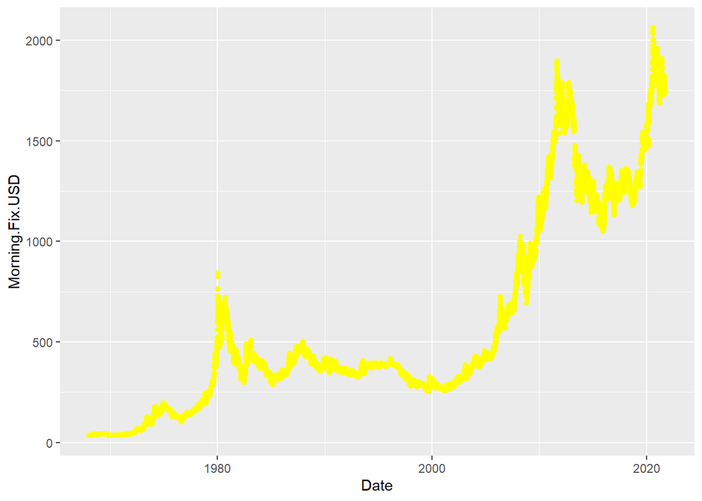

```r
ggplot(Gold.prices, aes(x = Date)) +
  geom_point(aes(y = Morning.Fix.USD), color = "yellow")
```

### World development indicators

#### Wczytywanie zbioru danych

```r
World_Development_Indicators <- read_excel("C:/Users/alili/Desktop/studia/9 semestr/ZED/projekt/Data pack/World_Development_Indicators.xlsx",
                                           na = '..',
                                           range = "A1:BC44305")

unique(World_Development_Indicators$`Country Name`)
```

```
##   [1] "Afghanistan"                    "Albania"
##   [3] "Algeria"                        "American Samoa"
##   [5] "Andorra"                        "Angola"
##   [7] "Antigua and Barbuda"            "Argentina"
##   [9] "Armenia"                        "Aruba"
##  [11] "Australia"                      "Austria"
##  [13] "Azerbaijan"                     "Bahamas, The"
##  [15] "Bahrain"                        "Bangladesh"
##  [17] "Barbados"                       "Belarus"
##  [19] "Belgium"                        "Belize"
##  [21] "Benin"                          "Bermuda"
##  [23] "Bhutan"                         "Bolivia"
##  [25] "Brazil"                         "British Virgin Islands"
##  [27] "Bulgaria"                       "Burundi"
##  [29] "Cambodia"                       "Cameroon"
```

[output cut: 89 more lines]

#### Czyszczenie zbioru:

- usunięcie elementów innych niż kraje z kolumny `Country Name`, pozostawienie całego swiata w zbiorze krajów,

```r
World_Development_Indicators <- World_Development_Indicators %>%
  filter(!`Country Name` %in% c("Low & middle income","Low income","Lower middle income","Middle income","Upper middle income","High income"))
```

- wyodrębnienie kodów serii do osobnej tabeli oraz usunięcie jej z przetwarzanego zbioru,
- przeniesienie zmiennych do osobnych kolumn,

```r
World_Development_Indicators.Series_Codes <- select(World_Development_Indicators, `Series Name`, `Series Code`)
World_Development_Indicators <- select(World_Development_Indicators, -`Series Code`)
```

- przeniesienie pojedyńczych obserwacji do osobnych wierszy

```r
World_Development_Indicators <- World_Development_Indicators %>%
  pivot_longer(cols = `1970 [YR1970]`:`2020 [YR2020]`, names_to = "Year") %>%
  group_by(`Series Name`) %>%
  mutate(row = row_number()) %>%
  tidyr::pivot_wider(names_from = `Series Name`, values_from = value) %>%
  select(-row)
```

- poprawa kolumny Year: wyodrębnienie lat jako numerycznych wartości

```r
World_Development_Indicators <- World_Development_Indicators %>%
  mutate(Year = as.numeric(substr(Year, 1, 4)))
```

#### Podsumowanie danych:

Zbiór zawiera pierdyliard wskaźników - trzeba wybrać potrzebne.

```r
ncol(World_Development_Indicators)
```

```
## [1] 216
```

```r
nrow(World_Development_Indicators)
```

```
## [1] 10302
```

```r
#summary(World_Development_Indicators)
```

### S&P Composite

#### Wczytywanie danych

```r
SP.Composite <- read.csv("C:/Users/alili/Desktop/studia/9 semestr/ZED/projekt/Data pack/S&P Composite.csv")
```

#### Czyszczenie danych:

- zmiana nazwy oraz typ na właściwy kolumny z datą
- zmiana nazwy Cyclicaly.Adjusted.PE.Ratio na skrót CAPE -

```r
SP.Composite <- SP.Composite %>%
  rename(Date = Year,
         CAPE = Cyclically.Adjusted.PE.Ratio) %>%
  mutate(Date = as.Date(Date))
```

#### Znaczenie atrybutów:

- S.P.Composite - nominalna wartość indexu,
- Divident - nominalna dywidenta,
- Earnings - nominalne zarobki na indeksie,
- CPI - wskaźnik cen towarów i usług konsumpcyjnych. Najpopularniejsza na świecie miara inflacji/deflacji,
- Long.Interest.Rate - stopy procentowe dziesięcioletnich obligacji rządowych,
- Real.Price - realna wartość indexu,
- Real.Divident - realna dywidenta,
- Real.Earnings - realne zarobki na indeksie,
- CAPE (Cyclicaly.Adjusted.PE.Ratio) - cyklicznie dostosowywany wskaźnik ceny do zysków. Definiuje się go jako cenę podzieloną przez średnią z dziesięciu lat zarobków, skorygowaną o inflację.

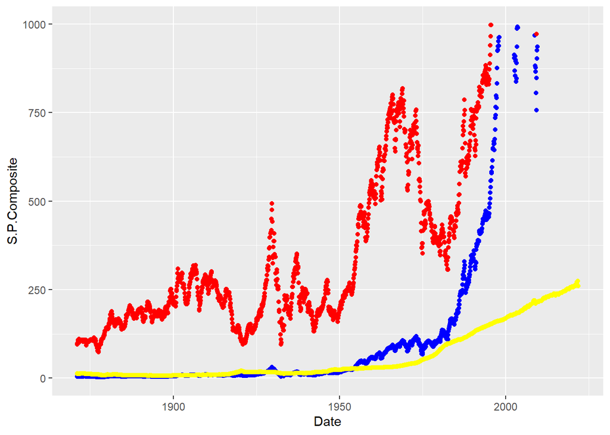

```r
SP.Composite %>%
  ggplot(aes(x=Date)) +
  geom_point(aes(y = S.P.Composite), color = "blue") +
  geom_point(aes(y = Real.Price), color = "red") +
  geom_point(aes(y = CPI), color = "yellow") +
  ylim(0, 1000)
```

#### Podsumowanie danych

```r
head(SP.Composite)
```

```
##         Date S.P.Composite Dividend Earnings      CPI Long.Interest.Rate
## 1 2021-10-31      3700.650       NA       NA 260.1097               0.93
## 2 2021-09-30      4493.280       NA       NA 273.9832               1.29
## 3 2021-08-31      4454.206       NA       NA 273.6565               1.28
## 4 2021-07-31      4363.713       NA       NA 273.0030               1.32
## 5 2021-06-30      4238.490 57.86504   158.74 271.6960               1.52
## 6 2021-05-31      4167.850 57.78782   148.56 269.1950               1.62
##   Real.Price Real.Dividend Real.Earnings     CAPE
## 1   3700.650            NA            NA 33.73946
## 2   4477.204            NA            NA 38.34228
## 3   4443.570            NA            NA 38.09043
## 4   4363.713            NA            NA 37.44349
## 5   4258.879      58.14340      159.5036 36.69631
## 6   4226.807      58.60528      150.6615 36.55215
```

```r
ncol(SP.Composite)
```

```
## [1] 10
```

```r
nrow(SP.Composite)
```

```
## [1] 1810
```

```r
summary(SP.Composite)
```

```
##       Date            S.P.Composite         Dividend          Earnings
##  Min.   :1871-01-31   Min.   :   2.730   Min.   : 0.1800   Min.   :  0.1600
##  1st Qu.:1908-10-07   1st Qu.:   7.902   1st Qu.: 0.4202   1st Qu.:  0.5608
##  Median :1946-06-15   Median :  17.370   Median : 0.8717   Median :  1.4625
##  Mean   :1946-06-15   Mean   : 327.968   Mean   : 6.7321   Mean   : 15.3714
##  3rd Qu.:1984-02-21   3rd Qu.: 164.400   3rd Qu.: 7.0525   3rd Qu.: 14.7258
##  Max.   :2021-10-31   Max.   :4493.280   Max.   :59.6800   Max.   :158.7400
##                                          NA's   :4         NA's   :4
##       CPI         Long.Interest.Rate   Real.Price     Real.Dividend
##  Min.   :  6.28   Min.   : 0.620     Min.   :  73.9   Min.   : 5.445
##  1st Qu.: 10.20   1st Qu.: 3.171     1st Qu.: 186.6   1st Qu.: 9.417
##  Median : 20.35   Median : 3.815     Median : 283.3   Median :14.411
##  Mean   : 62.39   Mean   : 4.504     Mean   : 622.0   Mean   :17.498
##  3rd Qu.:102.28   3rd Qu.: 5.139     3rd Qu.: 707.0   3rd Qu.:22.301
##  Max.   :273.98   Max.   :15.320     Max.   :4477.2   Max.   :63.511
##                                                       NA's   :4
##  Real.Earnings          CAPE
##  Min.   :  4.576   Min.   : 4.784
##  1st Qu.: 14.063   1st Qu.:11.898
##  Median : 23.524   Median :16.381
##  Mean   : 34.907   Mean   :17.215
##  3rd Qu.: 43.768   3rd Qu.:20.913
##  Max.   :159.504   Max.   :44.198
##  NA's   :4         NA's   :120
```

### Currency Exchange Rates

#### Wczytywanie danych:

```r
Currency.Exchange.Rates <- read.csv("C:/Users/alili/Desktop/studia/9 semestr/ZED/projekt/Data pack/CurrencyExchangeRates.csv")
```

#### Czyszczenie danych:

- zmiana typu kolumny z datą

```r
Currency.Exchange.Rates <- Currency.Exchange.Rates %>%
  mutate(Date = as.Date(Date))
```

#### Podsumowanie danych:

```r
ncol(Currency.Exchange.Rates)
```

```
## [1] 52
```

```r
nrow(Currency.Exchange.Rates)
```

```
## [1] 5978
```

```r
summary(Currency.Exchange.Rates)
```

```
##       Date            Algerian.Dinar   Australian.Dollar Bahrain.Dinar
##  Min.   :1995-01-02   Min.   : 71.29   Min.   :0.4833    Min.   :0.376
##  1st Qu.:2000-10-05   1st Qu.: 77.50   1st Qu.:0.6654    1st Qu.:0.376
##  Median :2006-07-06   Median : 81.28   Median :0.7595    Median :0.376
##  Mean   :2006-07-27   Mean   : 90.59   Mean   :0.7683    Mean   :0.376
##  3rd Qu.:2012-05-07   3rd Qu.:108.88   3rd Qu.:0.8689    3rd Qu.:0.376
##  Max.   :2018-05-02   Max.   :115.58   Max.   :1.1055    Max.   :0.376
##                       NA's   :4112     NA's   :263       NA's   :69
##  Bolivar.Fuerte     Botswana.Pula    Brazilian.Real  Brunei.Dollar
##  Min.   :    2.14   Min.   :0.0855   Min.   :0.832   Min.   :1.000
##  1st Qu.:    2.59   1st Qu.:0.1197   1st Qu.:1.709   1st Qu.:1.348
##  Median :    6.28   Median :0.1528   Median :2.048   Median :1.468
##  Mean   :  835.09   Mean   :0.1965   Mean   :2.161   Mean   :1.508
##  3rd Qu.:    6.28   3rd Qu.:0.1844   3rd Qu.:2.794   3rd Qu.:1.698
##  Max.   :68827.50   Max.   :4.8414   Max.   :4.195   Max.   :1.851
##  NA's   :3664       NA's   :1275     NA's   :539     NA's   :1246
##  Canadian.Dollar  Chilean.Peso    Chinese.Yuan   Colombian.Peso
##  Min.   :0.917   Min.   :377.5   Min.   :6.093   Min.   : 833.2
##  1st Qu.:1.086   1st Qu.:503.5   1st Qu.:6.495   1st Qu.:1786.0
##  Median :1.297   Median :538.6   Median :6.989   Median :2017.6
##  Mean   :1.268   Mean   :561.8   Mean   :7.316   Mean   :2073.1
##  3rd Qu.:1.409   3rd Qu.:619.8   3rd Qu.:8.277   3rd Qu.:2482.9
##  Max.   :1.613   Max.   :758.2   Max.   :8.746   Max.   :3434.9
##  NA's   :356     NA's   :1220    NA's   :1316    NA's   :582
##   Czech.Koruna    Danish.Krone        Euro        Hungarian.Forint
##  Min.   :14.45   Min.   :4.665   Min.   :0.8252   Min.   :144.1
##  1st Qu.:19.35   1st Qu.:5.612   1st Qu.:1.0889   1st Qu.:202.7
##  Median :21.88   Median :6.051   Median :1.2295   Median :224.3
##  Mean   :22.95   Mean   :6.281   Mean   :1.2076   Mean   :231.1
##  3rd Qu.:24.94   3rd Qu.:6.805   3rd Qu.:1.3338   3rd Qu.:267.6
##  Max.   :40.29   Max.   :9.006   Max.   :1.5990   Max.   :318.7
##  NA's   :1850    NA's   :251     NA's   :1070     NA's   :1415
##  Icelandic.Krona   Indian.Rupee   Indonesian.Rupiah  Iranian.Rial
##  Min.   : 54.72   Min.   :31.37   Min.   : 2201     Min.   : 1699
##  1st Qu.: 70.28   1st Qu.:42.82   1st Qu.: 8855     1st Qu.: 1755
##  Median : 83.48   Median :45.92   Median : 9260     Median : 8992
##  Mean   : 92.46   Mean   :48.02   Mean   : 9144     Mean   :10718
##  3rd Qu.:117.15   3rd Qu.:52.33   3rd Qu.:11380     3rd Qu.:11180
##  Max.   :147.98   Max.   :68.78   Max.   :14850     Max.   :42000
##  NA's   :354      NA's   :429     NA's   :1492      NA's   :1312
```

[output cut: 49 more lines]

```
##  Min.   : 5.843   Min.   :0.7253   Min.   :24.44   Min.   :5.839
##  1st Qu.: 6.838   1st Qu.:0.9777   1st Qu.:31.50   1st Qu.:6.260
##  Median : 7.618   Median :1.1878   Median :34.65   Median :6.282
##  Mean   : 7.741   Mean   :1.2090   Mean   :35.14   Mean   :6.310
##  3rd Qu.: 8.384   3rd Qu.:1.3903   3rd Qu.:39.45   3rd Qu.:6.382
##  Max.   :10.995   Max.   :1.8228   Max.   :56.06   Max.   :6.789
##  NA's   :349      NA's   :239      NA's   :565     NA's   :657
##  Tunisian.Dinar  U.A.E..Dirham   U.K..Pound.Sterling  U.S..Dollar
##  Min.   :1.342   Min.   :3.671   Min.   :1.213       Min.   :1
##  1st Qu.:1.566   1st Qu.:3.672   1st Qu.:1.519       1st Qu.:1
##  Median :1.723   Median :3.672   Median :1.599       Median :1
##  Mean   :1.850   Mean   :3.672   Mean   :1.615       Mean   :1
##  3rd Qu.:2.157   3rd Qu.:3.672   3rd Qu.:1.676       3rd Qu.:1
##  Max.   :2.509   Max.   :3.675   Max.   :2.102       Max.   :1
##  NA's   :4258    NA's   :71      NA's   :122
```

#### Analizy:

[output not shown]